# Topic 19

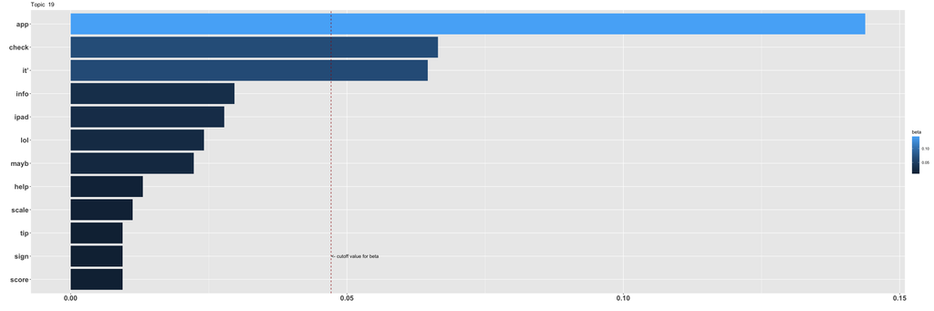

On interpreting beta: the term has a beta probability of being generated from the particular topic.

Values below are gamma : An estimated proportion of words from that document that are generated from that topic.

**Text Record Number: 31** gamma: 17 % likelihood of this document (based on its words) in this topic

Maybe you can check out the iPhone/iPad app ‘Paglano for piano’. It’s a simple shooting game for iPhone and iPad, by which you can train just one very small, but important aspect of reading music: finding the notes on your piano very quickly in all keys… This game is intended as a supplement to use at times and places when a piano is not available.  
More info about the app: www.paglano.com  
App Store: https://apps.apple.com/us/app/paglano/id1516800194

**Text Record Number: 41** gamma: 17 % likelihood of this document (based on its words) in this topic

Maybe you can check out the iPhone/iPad app ‘Paglano for piano’. It’s a simple shooting game for iPhone and iPad, by which you can train just one very small, but important aspect of reading music: finding the notes on your piano very quickly in all keys… This app is intended as a supplement to use at times and places when a piano is not available.  
More info about the app: www.paglano.com  
App Store: https://apps.apple.com/us/app/paglano/id1516800194

**Text Record Number: 50** gamma: 17 % likelihood of this document (based on its words) in this topic

Maybe you can check out the iPhone/iPad app ‘Paglano for piano’. It’s a simple shooting game for iPhone and iPad, by which you can train just one very small, but important aspect of reading music: finding the notes on your piano very quickly in all keys… So after that you can focus on all the other aspects of playing piano more easily.  
More info about the app: www.paglano.com  
App Store: https://apps.apple.com/us/app/paglano/id1516800194

**Text Record Number: 47** gamma: 17 % likelihood of this document (based on its words) in this topic

Maybe you can check out the iPhone/iPad app ‘Paglano for piano’. It’s a simple shooting game for iPhone and iPad, by which you can train just one very small, but important aspect of reading music: finding the notes on your piano very quickly in all keys… This app is intended as a supplement to use at times and places when a piano is not available, but is certainly not a substitute for a real piano, of course.  
More info about the app: www.paglano.com  
App Store: https://apps.apple.com/us/app/paglano/id1516800194

**Text Record Number: 48** gamma: 17 % likelihood of this document (based on its words) in this topic

Maybe you can check out the iPhone/iPad app ‘Paglano for piano’. It’s a simple shooting game for iPhone and iPad, by which you can train just one very small, but important aspect of reading music: finding the notes on your piano very quickly in all keys… This app is intended as a supplement to use at times and places when a piano is not available, but is certainly not a substitute for a real piano, of course.  
More info about the app: www.paglano.com  
App Store: https://apps.apple.com/us/app/paglano/id1516800194

**Text Record Number: 46** gamma: 17 % likelihood of this document (based on its words) in this topic

**Maybe you can check out the iPhone/iPad app ‘Paglano for piano’. It’s a simple shooting game for iPhone and iPad, by which you can train just one very small, but important aspect of reading music: finding the notes on your piano very quickly in all keys… So after playing it several times you can focus more on all the other aspects of reading sheet music and hopefully it becomes less frustrating.

More info about the app: www.paglano.com  
App Store: https://apps.apple.com/us/app/paglano/id1516800194**

**Text Record Number: 45** gamma: 17 % likelihood of this document (based on its words) in this topic

Maybe you can check out the iPhone/iPad app ‘Paglano for piano’. It’s a simple shooting game for iPhone and iPad, by which you can train just one very small, but important aspect of reading music: finding the notes on your piano very quickly in all keys… After playing it a lot you don’t have to count the notes anymore and you can focus more on all the other aspects of reading sheet music (This app is intended as a supplement to use at times and places when a piano is not available, but is certainly not a substitute for a real piano, of course…).  
More info about the app: www.paglano.com  
App Store: https://apps.apple.com/us/app/paglano/id1516800194